# Session 7

Ecological Data Collection and Processing: Exercises

Ward Fonteyn & Stef Haesen

02/12/2021

# Session 7: Classification

## Classification

- Hierarchical clustering (unsupervised, hierarchical)
- K means (unsupervised, non-hierarchical)
- K nearest neighbours (supervised)

Goal: group data in similar classes

## Data

```r
library(datasets)
data(iris, package = "datasets")
```

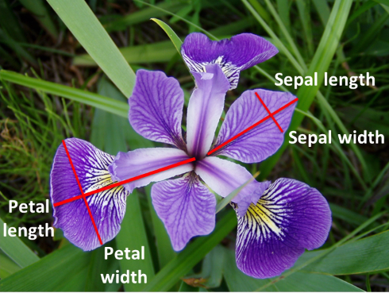

## Exercises (30 min)

**Hierarchical clustering**

- Construct a dissimilarity matrix for the sepal length
- Perform an agglomerative hierarchical clustering of the dataset
  - based upon the sepal length
  - **TIP**: cluster package
- Plot the dendrogram of the performed clustering
  - change the output from the agglomerative clustering into a hclust object
- Find the optimum number of clusters
  - **TIP**: stats package
- How does the clustering changes when you use 4 clusters instead of 3?
- Visualize the different clusters by plotting rectangles on the dendrogram

## Check data

```r
str(iris)
```

```
## 'data.frame':    150 obs. of  5 variables:
##  $ Sepal.Length: num  5.1 4.9 4.7 4.6 5 5.4 4.6 5 4.4 4.9 ...
##  $ Sepal.Width : num  3.5 3 3.2 3.1 3.6 3.9 3.4 3.4 2.9 3.1 ...
##  $ Petal.Length: num  1.4 1.4 1.3 1.5 1.4 1.7 1.4 1.5 1.4 1.5 ...
##  $ Petal.Width : num  0.2 0.2 0.2 0.2 0.2 0.4 0.3 0.2 0.2 0.1 ...
##  $ Species     : Factor w/ 3 levels "setosa","versicolor",..: 1 1 1 1 1 1 1 1 1 1 ...
```

## Check data

```r
max <- apply(iris[, 1:4], 2, function(x){max(x, na.rm = T)})
min <- apply(iris[, 1:4], 2, function(x){min(x, na.rm = T)})
```

## Check data

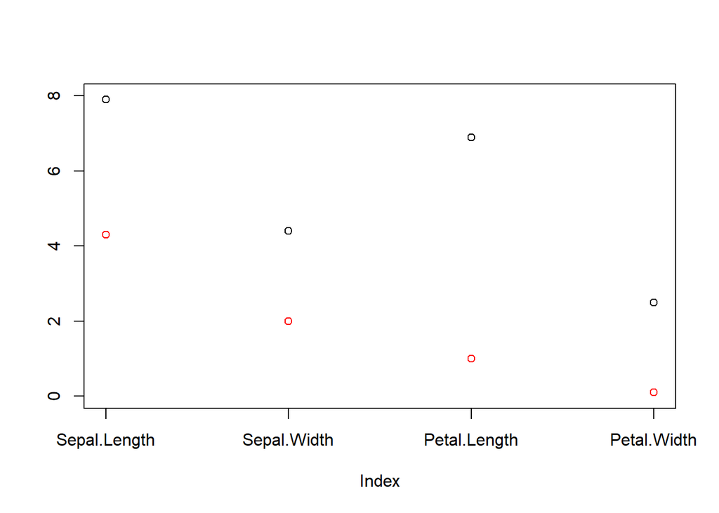

```r
plot(max, xaxt = "n", ylim = c(0,8), ylab = " ")
axis(1, at = 1:4, labels = colnames(iris[1:4]))
points(min, col = "red")
```

## Load all necessary packages

```r
library(cluster)
library(stats)
library(vegan)
```

## Hierarchical clustering (1)

```r
# Construct a dissimilarity matrix for the sepal length
# Euclidean distance for quantitative data
dis.eu <- vegdist(iris$Sepal.Length, method="euclidean", na.rm = TRUE)

# Perform an agglomerative hierarchical clustering of the dataset
cluster_single <- agnes(dis.eu,method = "single")
cluster_complete <- agnes(dis.eu,method = "complete")
cluster_ward <- agnes(dis.eu,method = "ward")
cluster_average <- agnes(dis.eu,method = "weighted")
cluster_flexible <- agnes(dis.eu,method = "flexible", par.method = 0.625) # alpha 0.625 gives beta -0.25


cluster_single <- as.hclust(cluster_single)
cluster_complete <- as.hclust(cluster_complete)
cluster_ward <- as.hclust(cluster_ward)
cluster_average <- as.hclust(cluster_average)
cluster_flexible <- as.hclust(cluster_flexible)
```

## Hierarchical clustering (2)

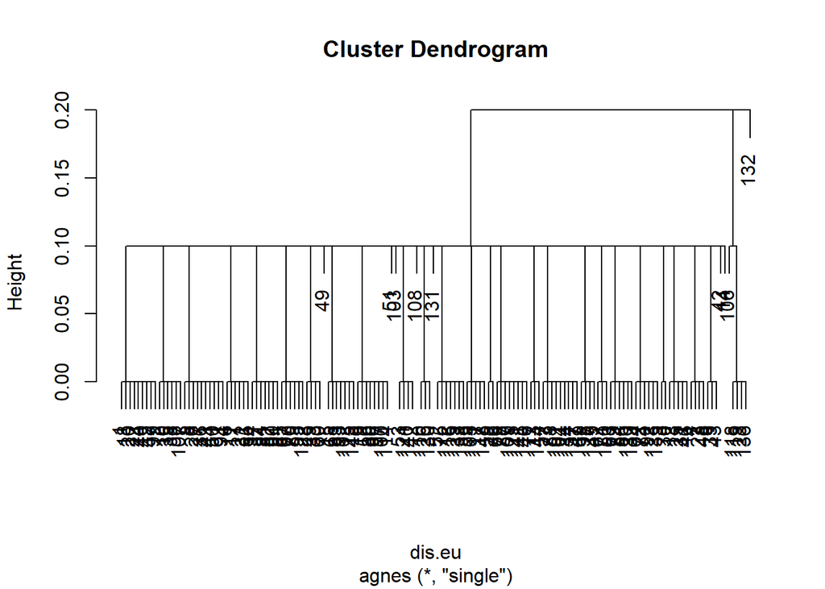

```r
plot(cluster_single)
```

## Hierarchical clustering (3)

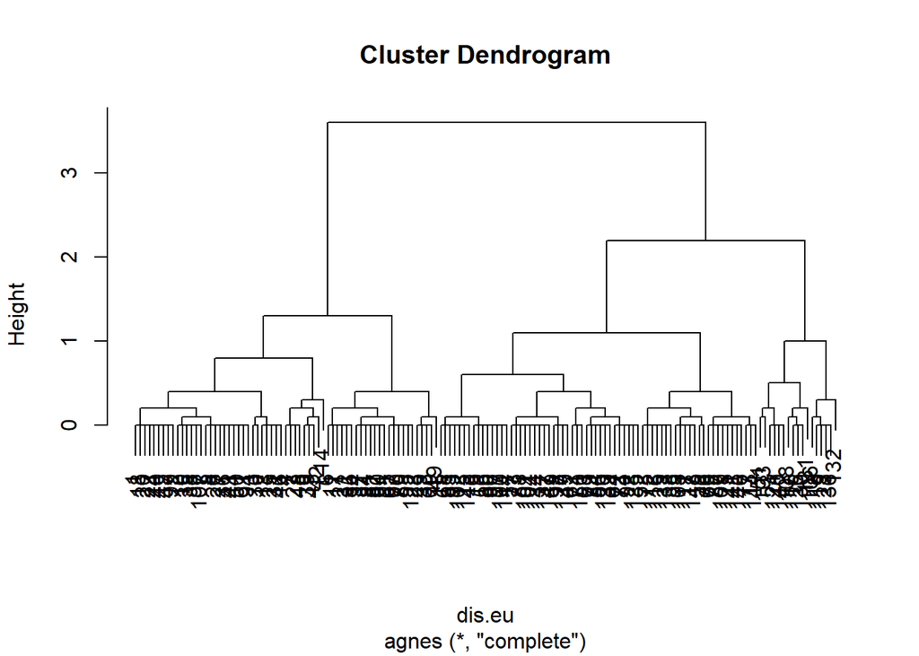

```r
plot(cluster_complete)
```

## Hierarchical clustering (4)

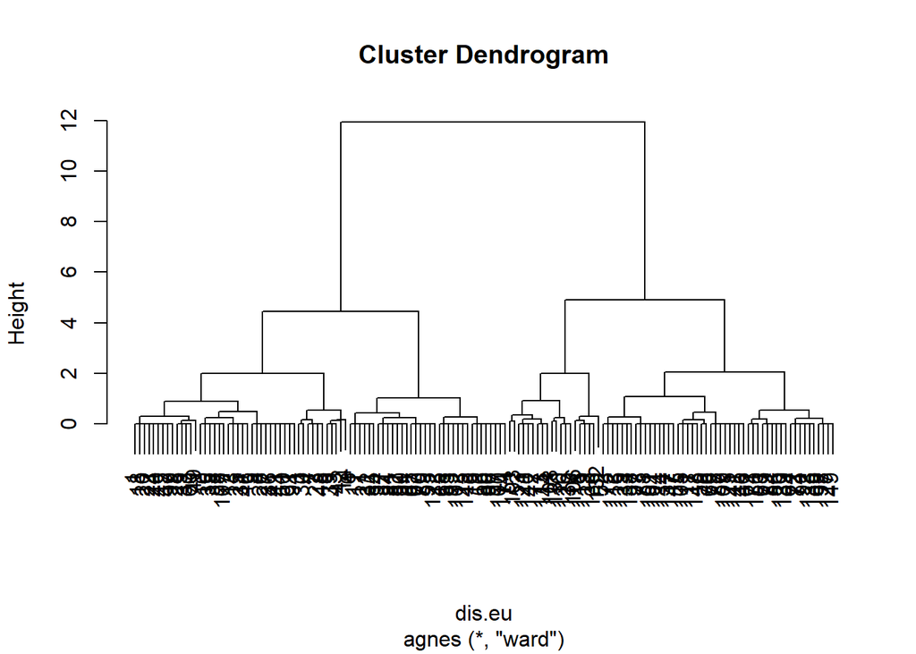

```r
plot(cluster_ward)
```

## Hierarchical clustering (5)

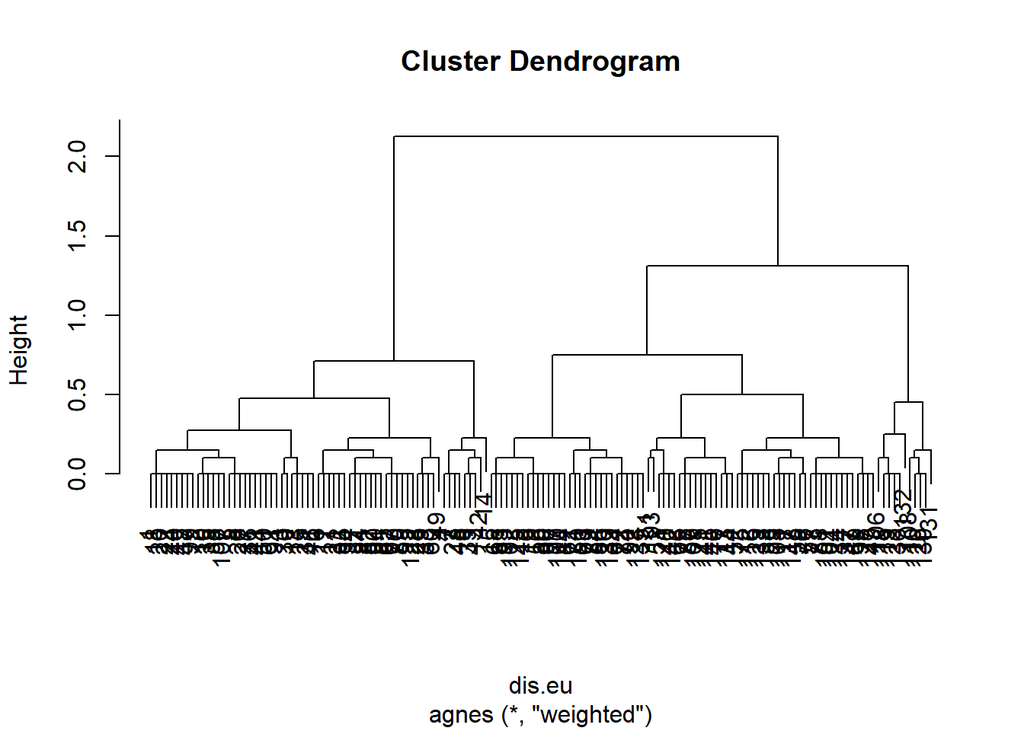

```r
plot(cluster_average)
```

## Hierarchical clustering (6)

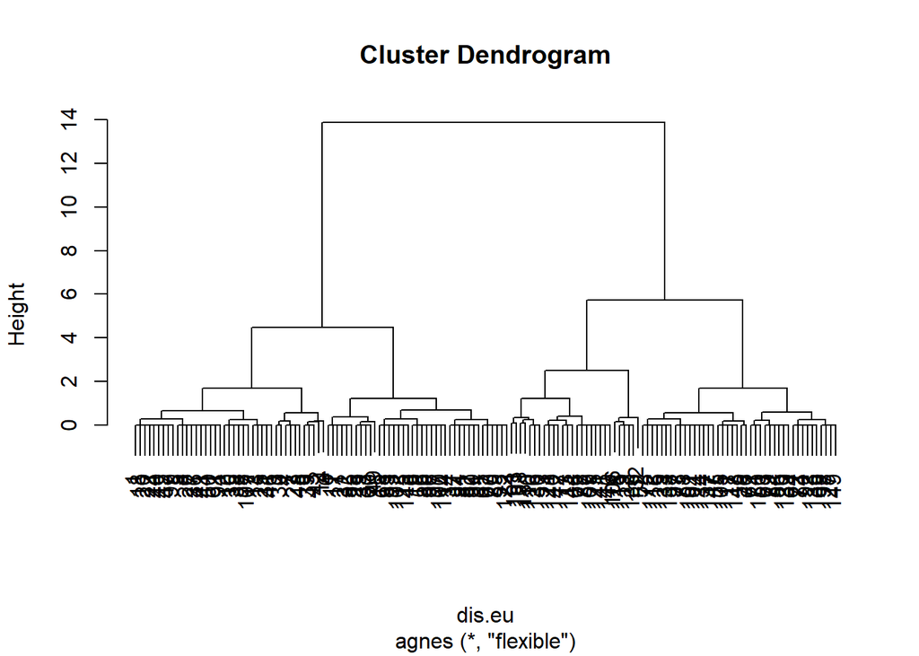

```r
plot(cluster_flexible)
```

## Hierarchical clustering (7)

Difficult to visually check which method is best, but:

- Space conserving method preferred
- Average, Ward, Flexible

Recommendation:

- Ward’s method with Euclidean distance
- Flexible beta (-0.25) with Bray-Curtis or Sorensen (species data!!)

## Hierarchical clustering (8)

```r
# Alternative = cophenetic correlation coefficient
# Evaluate how well the dendrogram represents the original dissimilarity matrix
coph_ward <- cophenetic(cluster_ward)
coph_average <- cophenetic(cluster_average)

# Both score about the same
cor(dis.eu, coph_ward)
```

```
## [1] 0.6890892
```

```r
cor(dis.eu, coph_average)
```

```
## [1] 0.6819246
```

## Hierarchical clustering (9)

```r
# Find the optimum number of clusters (Total within-cluster Sums of Squares)

set.seed(1)
k.max <- 10
wss <- sapply(1:k.max,
              function(x){kmeans(iris[, 1], x, nstart = 20, iter.max = 20)$tot.withinss})
```

## Hierarchical clustering (10)

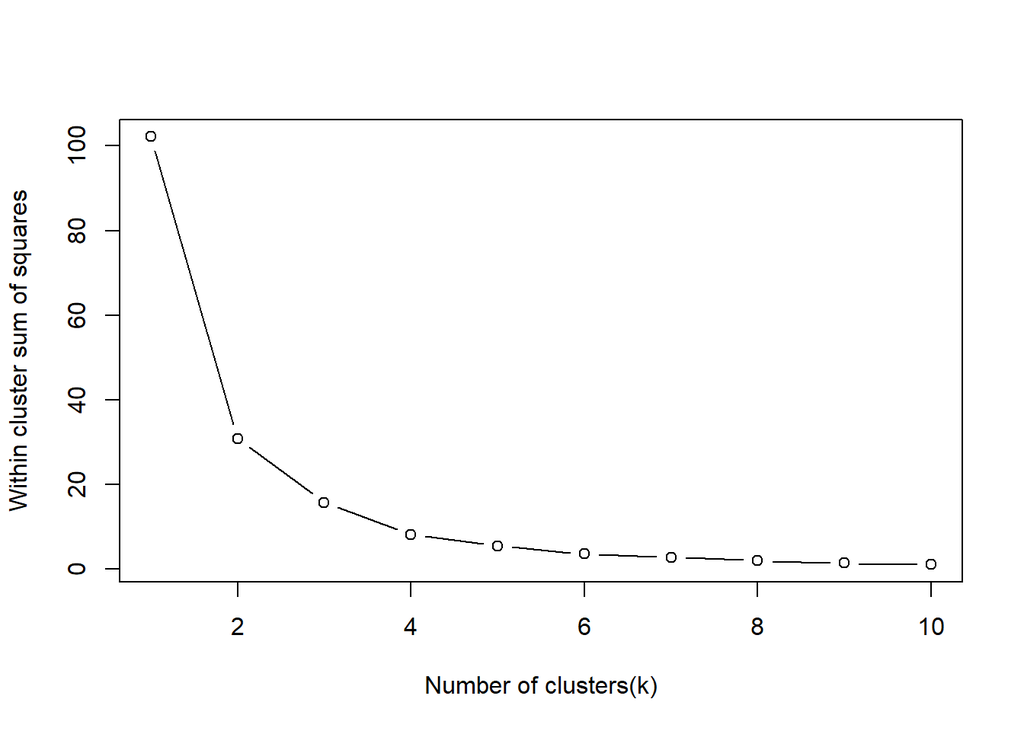

```r
# Visual representation
plot(1:k.max, wss , type= "b", xlab = "Number of clusters(k)",
      ylab = "Within cluster sum of squares")
```

## Hierarchical clustering (11)

```r
# What changes when you classify the dendrogram with 3 clusters or 4 clusters?
clusters_three <- table(cutree(cluster_ward, 3))
clusters_three
```

```
##
##  1  2  3
## 80 20 50
```

```r
clusters_four <- table(cutree(cluster_ward, 4))
clusters_four
```

```
##
##  1  2  3  4
## 46 34 20 50
```

## Hierarchical clustering (12)

```r
# We see that cluster 1 is split in two new cluster (from 80 to 46 & 34)
clusters_difference <- table(cutree(cluster_ward, 3), cutree(cluster_ward, 4))
clusters_difference
```

```
##
##      1  2  3  4
##   1 46 34  0  0
##   2  0  0 20  0
##   3  0  0  0 50
```

## Hierarchical clustering (13)

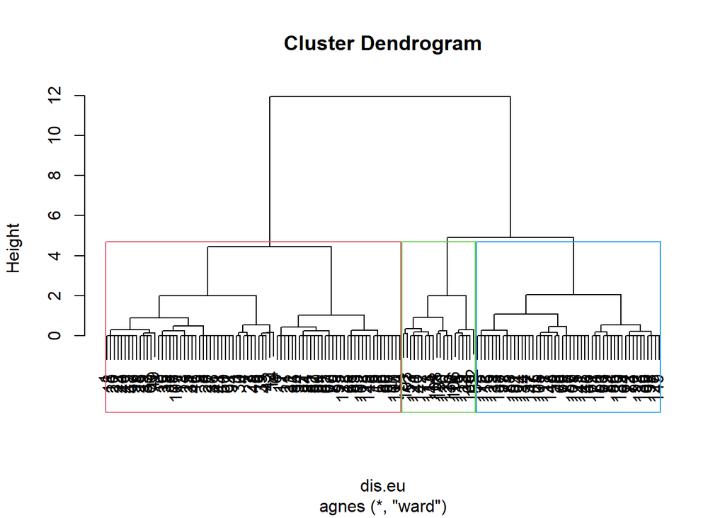

```r
# Visualize the different clusters by plotting rectangles on the dendrogram
plot(cluster_ward)
rect.hclust(cluster_ward , k = 3, border = 2:6)
```

## Exercises (15 min)

**K means**

- Cluster using petal length and width
- Find the optimum number of clusters
  - **TIP**: cluster package
- Visualize the clustering using ggplot2

## K means (1)

```r
# Find the optimum number of clusters (GAP method)
set.seed(1)
gap_stat <- clusGap(iris[, 3:4], FUN = kmeans, nstart = 20, K.max = 10, B = 50)
k <- maxSE(gap_stat$Tab[, "gap"], gap_stat$Tab[, "SE.sim"], method="Tibs2001SEmax")
k
```

```
## [1] 3
```

## K means (2)

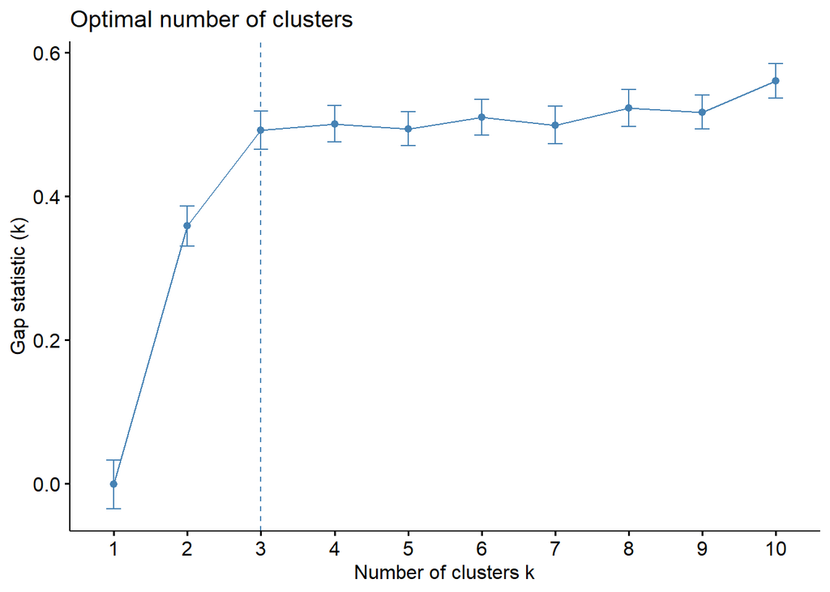

```r
library(factoextra)
fviz_gap_stat(gap_stat)
```

## K means (3)

```r
# Perform a K means clustering of the iris dataset
Kclustering <- kmeans(iris[,3:4], 3, nstart = 20)
table(Kclustering$cluster,iris$Species)
```

```
##
##     setosa versicolor virginica
##   1      0         48         4
##   2      0          2        46
##   3     50          0         0
```

## K means (4)

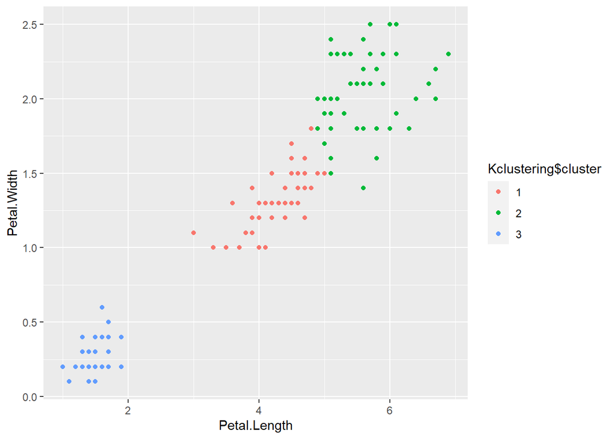

```r
# Visualize the clustering using ggplot2
Kclustering$cluster <- as.factor(Kclustering$cluster)
ggplot(iris, aes(Petal.Length, Petal.Width, color = Kclustering$cluster)) + geom_point()
```

## Exercises (15 min)

**K nearest neighbours**

- Cluster using all four variables
- Split data into random training and random testing sets using a random 70%-30% split
- Find the optimum number of neighbours
  - **TIP**: class package
- Visualize the clustering using ggplot2

## K nearest neighbours (1)

```r
# random sample a training dataset and a testing dataset
set.seed(1)
trainrows <- sample(1:nrow(iris), replace = F, size = 0.7*nrow(iris))
train_iris <- iris[trainrows, 1:4]
test_iris <- iris[-trainrows, 1:4]
train_response <- iris[trainrows, 5]
test_response <- iris[-trainrows, 5]
```

## K nearest neighbours (2)

```r
# Find the optimum number of neighbours
library(class)
error <- c()
for (i in 1:60) {
  knn.fit <- knn(train = train_iris, test = test_iris, cl = train_response, k = i)
  error[i] = 1 - mean(knn.fit == test_response)
}
```

## K nearest neighbours (3)

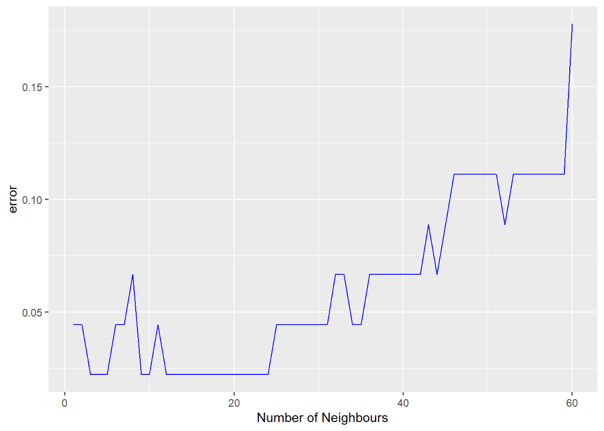

```r
# This result can differ due to knn's method to resolve ties
ggplot(data = data.frame(error), aes(x = 1:60, y = error)) +
  geom_line(color = "Blue") + xlab("Number of Neighbours")
```

## K nearest neighbours (4)

```r
# Calculate the prediction accuracy using the chosen K value
set.seed(1)
iris_pred <- knn(train = train_iris, test = test_iris, cl = train_response, k = 20)
predicted_classification <- cbind(test_iris, iris_pred)
true_classification <- cbind(test_iris, test_response)
```

## K nearest neighbours (6)

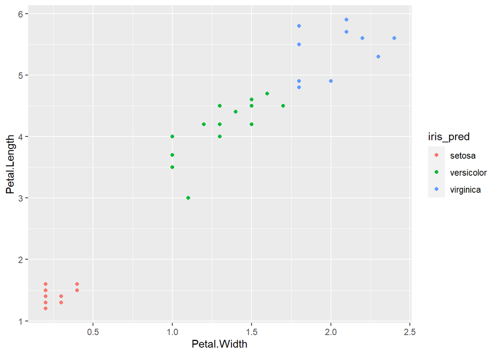

```r
# Visualize the predicted classes using ggplot2
ggplot(predicted_classification, aes(x=Petal.Width, y=Petal.Length, color=iris_pred))+
  geom_point()
```

## K nearest neighbours (6)

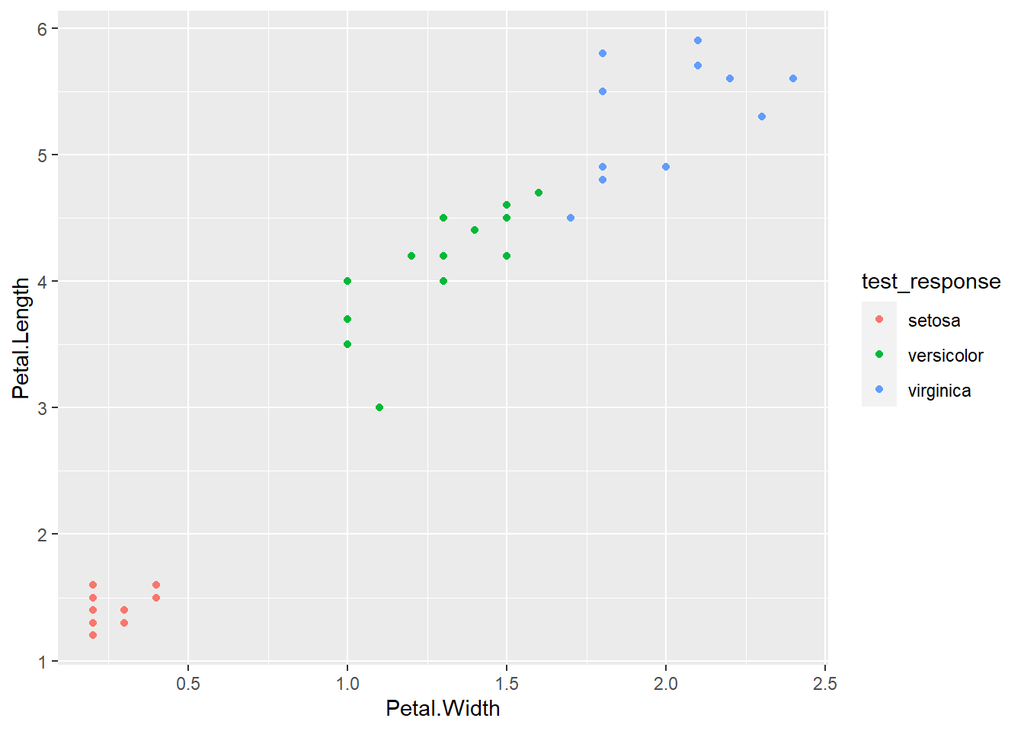

```r
# Visualize the true classes using ggplot2
ggplot(true_classification, aes(x=Petal.Width, y=Petal.Length, color=test_response))+
  geom_point()
```

## K nearest neighbours (7)

Need an extra challenge?

- Try performing K nearest neighbours with cross-validation in R
- Tip: caret-package

## Exercises (30 min)

**Indicator species analysis**

- Use the varespec dataset
- Divide the species data in clusters
- Find indicator species for each cluster
  - **TIP**: indicspecies package

## Indicator species analysis (1)

```
## 'data.frame':    24 obs. of  44 variables:
##  $ Callvulg: num  0.55 0.67 0.1 0 0 ...
##  $ Empenigr: num  11.13 0.17 1.55 15.13 12.68 ...
##  $ Rhodtome: num  0 0 0 2.42 0 0 1.55 0 0.35 0.07 ...
##  $ Vaccmyrt: num  0 0.35 0 5.92 0 ...
##  $ Vaccviti: num  17.8 12.1 13.5 16 23.7 ...
##  $ Pinusylv: num  0.07 0.12 0.25 0 0.03 0.12 0.1 0.1 0.05 0.12 ...
##  $ Descflex: num  0 0 0 3.7 0 0.02 0.78 0 0.4 0 ...
##  $ Betupube: num  0 0 0 0 0 0 0.02 0 0 0 ...
##  $ Vacculig: num  1.6 0 0 1.12 0 0 2 0 0.2 0 ...
##  $ Diphcomp: num  2.07 0 0 0 0 0 0 0 0 0.07 ...
##  $ Dicrsp  : num  0 0.33 23.43 0 0 ...
##  $ Dicrfusc: num  1.62 10.92 0 3.63 3.42 ...
##  $ Dicrpoly: num  0 0.02 1.68 0 0.02 0.02 0 0.23 0.2 0 ...
##  $ Hylosple: num  0 0 0 6.7 0 0 0 0 9.97 0 ...
```

[output cut: 30 more lines]

## Indicator species analysis (2)

```r
A<-vector()
B<-vector()

#perform NMDS for 1, 2, 3 and 4 dimensions
for (i in 1:4) {
  NDMS<-metaMDS(varespec, distance = "bray",k=i, autotransform = TRUE, trymax=100 )
  solution<-NDMS$converged
  stress<-NDMS$stress
  A1<-cbind(solution,stress)
  j=i+1
  B<-rbind(B,j-1)
  A<-rbind(A,A1)
}
```

```
## Square root transformation
## Wisconsin double standardization
## *** No convergence -- monoMDS stopping criteria:
##    100: scale factor of the gradient < sfgrmin
## Square root transformation
## Wisconsin double standardization
## *** Solution reached
## Square root transformation
## Wisconsin double standardization
## *** Solution reached
## Square root transformation
## Wisconsin double standardization
## *** Solution reached
```

## Indicator species analysis (3)

```r
NMDSoutput<-data.frame(B,A)
names(NMDSoutput) <- c("k","Solution?","Stress")
NMDSoutput
```

```
##   k Solution?     Stress
## 1 1         0 0.34876961
## 2 2         1 0.18256581
## 3 3         1 0.11516665
## 4 4         1 0.07735424
```

## Indicator species analysis (4)

```r
k<-4
NMDSfinal<-metaMDS(varespec, distance = "bray", k=k, autotransform = TRUE, trymax=100)
```

```
## Square root transformation
## Wisconsin double standardization
## *** Solution reached
```

## Indicator species analysis (5)

```r
# Find the optimum number of clusters (Total within-cluster Sums of Squares)
set.seed(1)
k.max <- 10
wss <- c()
for (i in 1:k.max) {
  wss[i] <- kmeans(NMDSfinal$points, i, nstart = 20, iter.max = 20)$tot.withinss
}
```

## Indicator species analysis (6)

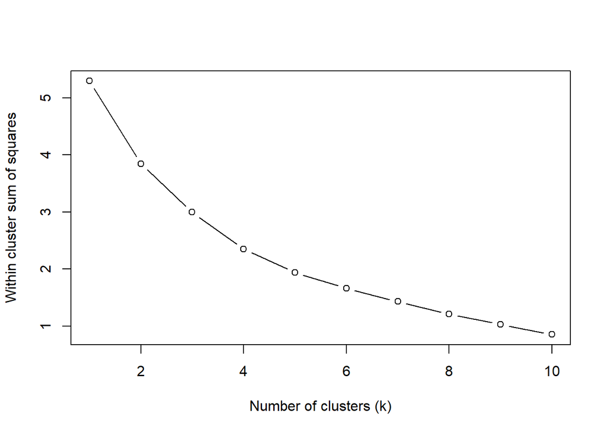

```r
# Find the optimum number of clusters (Total within-cluster Sums of Squares)
plot(1:k.max, wss , type= "b", xlab = "Number of clusters (k)",
            ylab = "Within cluster sum of squares")
```

## Indicator species analysis (6)

```r
# Find the optimum number of clusters (GAP method)
set.seed(1)
gap_stat <- clusGap(NMDSfinal$points, FUN = kmeans, nstart = 20, K.max = 10, B = 50)
k <- maxSE(gap_stat$Tab[, "gap"], gap_stat$Tab[, "SE.sim"], method="Tibs2001SEmax")
k
```

```
## [1] 1
```

## Indicator species analysis (7)

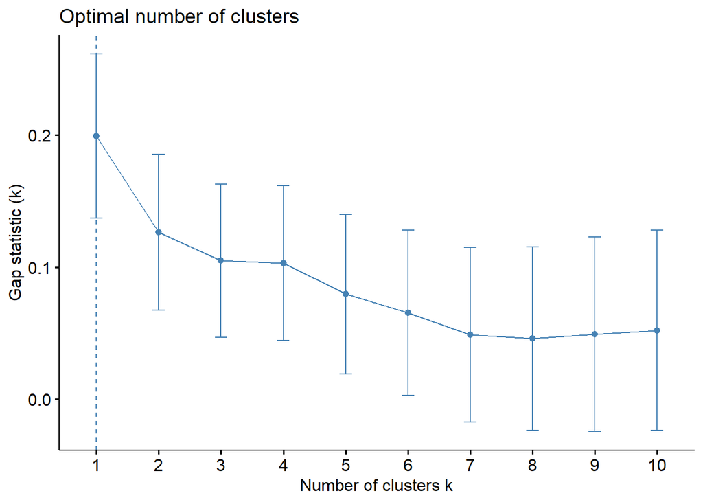

```r
# Find the optimum number of clusters (GAP method)
fviz_gap_stat(gap_stat)
```

## Indicator species analysis (8)

```r
# Perform a K means clustering of the iris dataset
Kclustering <- kmeans(NMDSfinal$points, 3, nstart = 20)
Kclustering$cluster
```

```
## 18 15 24 27 23 19 22 16 28 13 14 20 25  7  5  6  3  4  2  9 12 10 11 21
##  2  2  3  1  2  2  2  2  1  2  2  2  2  2  2  2  2  2  3  3  3  3  3  1
```

## Indicator species analysis (9)

```r
library(indicspecies)
inv <- multipatt(varespec, Kclustering$cluster, func = "r.g", control = how(nperm=9999))
```

## Indicator species analysis (10)

```r
summary(inv)
```

## Indicator species analysis (11)

```
##
##  Multilevel pattern analysis
##  ---------------------------
##
##  Association function: r.g
##  Significance level (alpha): 0.05
##
##  Total number of species: 44
##  Selected number of species: 12
##  Number of species associated to 1 group: 12
##  Number of species associated to 2 groups: 0
##
##  List of species associated to each combination:
##
##  Group 1  #sps.  8
##           stat p.value
## Vaccmyrt 0.883  0.0008 ***
## Rhodtome 0.758  0.0007 ***
## Hylosple 0.734  0.0068 **
## Polycomm 0.631  0.0215 *
## Descflex 0.621  0.0009 ***
## Pleuschr 0.609  0.0226 *
## Cladbotr 0.551  0.0210 *
## Barbhatc 0.513  0.0053 **
##
##  Group 2  #sps.  1
##           stat p.value
## Cladarbu 0.719  0.0058 **
##
##  Group 3  #sps.  3
##           stat p.value
## Cladstel 0.759  0.0049 **
## Cladphyl 0.625  0.0308 *
## Pinusylv 0.592  0.0150 *
## ---
## Signif. codes:  0 '***' 0.001 '**' 0.01 '*' 0.05 '.' 0.1 ' ' 1
```

## Assignment 5

Access the assignment:

```r
vignette("assignment-5", package = "edcpR")
```

Submit your R-script as **Surname_FirstName_assignment5.R**

Upload everything on Toledo before **December 8, 12 pm** (= at noon)!